```python
# Utils

from IPython.display import Image
```

# Tutorial: Latent Dirichlet Allocation

## Introduction

This notebook describes in painful detail the Gibbs sampling algorithm for Latent Dirichlet Allocation. It is based on "Finding scientific topics", the PNAS paper by Griffiths and Steyvers ( [link](http://psiexp.ss.uci.edu/research/papers/sciencetopics.pdf) ), and not the original paper by Blei et al.

## Probabilistic Model and Generative Story

We assume the following generative story for document creation:

A number of $D$ documents are generated independently. There are a number of $T$ topics that characterize the documents. There are $W$ unique words in the documents. Each document has a length of $L_d$ words.

Each document $d$ has a topic distribution $\theta_d$, a categorical distribution with $T$ categories (and there are $D$ such distributions).

Each topic $t$ has a word distribution $\phi_t$, a categorical distribution with $W$ categories (and there are $T$ such distributions).

To generate a document, we generate each word independently. For each document $d$ and word position $l$, a topic corresponding to that position is sampled from the topic distribution:

$P(z_{dl} = t) = \theta_d(t)$

According to the sampled topic, the word is generated according to:

$P(w_{dl} = w) = \phi_{z_{dl}}(w)$

We place Dirichlet conjugate priors on $\theta$:

$\theta \sim Dirichlet(\alpha)$

and $\phi$:

$\phi \sim Dirichlet(\beta)$.

Furthermore, to simplify things, we assume $\alpha$ and $\beta$ are symmetric priors, and in experiments we initalize them to $1$.

The probabilistic model in plate model notation is illustrated below:

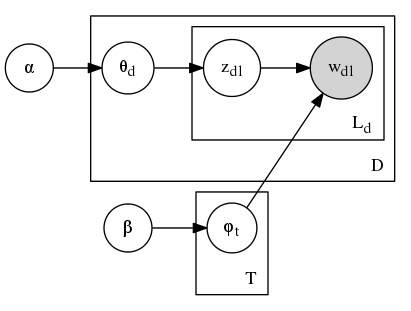

```python
lda_pm = Image(filename='images/lda_pm.png')
lda_pm
```

The joint distribution is:

$P(w,z, \theta, \phi ; \alpha, \beta) = P(\theta ; \alpha) P(z | \theta) P(\phi ; \beta) P(w | z,\phi)$

## Integrating out $\theta$ and $\phi$

\begin{align*} P(w,z ; \alpha, \beta) &= P(\theta ; \alpha) P(z | \theta) P(\phi ; \beta) P(w | z,\phi)\\ &= \int_{\phi} \int_{\theta} P(\theta ; \alpha) P(z | \theta) P(\phi ; \beta) P(w | z,\phi)\\ &= \int_{\phi} P(\phi ; \beta) P(w | z,\phi) \int_{\theta} P(\theta ; \alpha) P(z | \theta)\\ &= f_1 f_2 \end{align*}

\begin{align*} f_1 &= \int_{\phi} (\prod_t P(\phi_t ; \beta)) (\prod_d \prod_l P(w_{dl} | z_{dl}, \phi))\\ &= \int_{\phi} \prod_t (\frac{\Gamma(\beta W)}{\prod_w \Gamma(\beta)} \prod_w \phi_t(w)^{\beta-1})\prod_d \prod_l \phi_{z_{dl}}(w_{dl})\\ &= k_1 \int_{\phi} \prod_t \prod_w \phi_t(w)^{\beta-1} \prod_t \prod_w \phi_t(w)^{n(w,t)}\\ &= k_1 \int_{\phi} \prod_t \prod_w \phi_t(w)^{n(w,t)+\beta-1}\\ &= k_1 \prod_t \int_{\phi_t} \prod_w \phi_t(w)^{n(w,t)+\beta-1}\\ &= k_1 \prod_t \frac{\prod_w \Gamma(n(w,t)+\beta)}{\Gamma(\sum_w (n(w,t)+\beta))}\\ &= k_1 \prod_t \frac{\prod_w \Gamma(n(w,t)+\beta)}{\Gamma(n(t)+\beta W)} \end{align*}

Where:

$k_1 = \left(\frac{\Gamma(\beta W)}{\Gamma(\beta)^W}\right)^T$

$n(w,t)$ is the number of times word $w$ has been assigned to topic $t$ in all documents

and

$n(t)$ is the number of words assigned to topic $t$ in all documents.

The exact same steps can be applied to compute $f_2$ as:

$$ f_2 = k_2 \prod_d \frac{\prod_t \Gamma(n(d,t)+\alpha)}{\Gamma(n(d)+\alpha T)} $$

Where:

$k_2 = \left(\frac{\Gamma(\alpha T)}{\Gamma(\alpha)^T}\right)^D$

$n(d,t)$ is the number of times a word from document $d$ has been assigned to topic $t$

and

$n(d)$ is the number of words in document $d$, i.e. $L_d$ from the plate notation.

## Gibbs sampling

$$f_1 = P(w|z)$$ $$f_2 = P(z)$$

The goal of the sampling procedure is to estimate $\phi$ and $\theta$. $\phi$ informs us what the topics might be, $\theta$ tells us how important each topic is in a document. But we have just integrated them out! Instead of sampling the values directly, we will estimate them based on sampling $P(z|w)$.

$P(z|w) \varpropto P(w|z)P(z)$

!!!!!!!!!!!!!!!!!!!!!!!!!!! What follows is my attempt at Gibbs sampling !!!!!!!!!!!!!!!!!!!!!!!!!!!

In the paper, $z$ seems to be split into $D$ components, and the Gibbs sampler updates are:

$$ P(z_i=j|z_{-i}, w) \varpropto \frac{n_{-i,j}^{w_i} + \beta}{n_{-i,j}^{*} + W\beta} \frac{n_{-i,j}^{d_i} + \alpha}{n_{-i,*}^{d_i} + T\alpha} $$

I did not manage to map the counts notations, e.g. $n_{-i,j}^{w_i}$ to a clear semantic meaning, nor did I obtain similar updates when attempting the same split into components.

However, I obtained *something* by splitting $z$ into $D*L_d$ components, i.e. by considering sampling a topic for each position in a document.

Concretely, we update:

$$P(z_{ij}=k | z_{-ij}, w)$$

Where $i$ is a document index, $j$ is a position in document $i$, and $k$ is a topic. $z_{ij}$ is the topic of word $w_{ij}$. All the other assignments $z_{-ij}$ are assumed to be known.

$$P(z_{ij}=k | z_{-ij}, w) = \frac{P(z_{ij}=k, z_{-ij}, w)}{P(z_{-ij}, w)} = \frac{f_1}{g_1} \frac{f_2}{g_2}$$

$$g_1 = p(w|z_{-ij})$$

$$g_2 = p(z_{-ij})$$

$g_1$, resp. $g_2$ are similar to $f_1$, resp. $f_2$ except that we don't count the assignment $z_{ij}=k$, i.e.

$$g_1 = k_1 (\prod_{t\neq k} \frac{\prod_w \Gamma(n(w,t)+\beta)}{\Gamma(n(t)+\beta W)}) \frac{(\prod_{w\neq w_{ij}} \Gamma(n(w,k)+\beta))\Gamma(n(w_{ij},k)-1 +\beta)}{\Gamma(n(k)-1+\beta W)}$$

Consequently:

$$ \frac{f_1}{g_1} = \frac{\Gamma(n(w_{ij},k)+\beta)}{\Gamma(n(k)+\beta W)} \frac{\Gamma(n(k)-1+\beta W)}{\Gamma(n(w_{ij},k)-1 +\beta)} = \frac{n(w_{ij},k)-1+ \beta}{n(k)-1+\beta W} $$

Similarly:

$$g_2 = k_2 ( \prod_{d\neq i} \frac{\prod_t \Gamma(n(d,t)+\alpha)}{\Gamma(n(d)+\alpha T)} ) \frac{ (\prod_{t \neq k} \Gamma(n(i,t)+\alpha)) \Gamma(n(i,k)-1+\alpha)}{\Gamma(n(i)-1+\alpha T)}$$

Then:

$$ \frac{f_2}{g_2} = \frac{\Gamma(n(i,k)+\alpha)}{\Gamma(n(i)+\alpha T)} \frac{\Gamma(n(i)-1+\alpha T)}{\Gamma(n(i,k)-1+\alpha)} = \frac{n(i,k)-1+\alpha}{n(i)-1+\alpha T} $$

Finally, the update is:

$$P(z_{ij}=k | z_{-ij}, w) \varpropto \frac{n(w_{ij},k)-1+ \beta}{n(k)-1+\beta W}\frac{n(i,k)-1+\alpha}{n(i)-1+\alpha T}$$

We compute this value for all $k = \lbrace 1, \dots, T\rbrace$, and sample:

$$z^{(next)}_{ij} \sim Cat(P(z_{ij}| z_{-ij}, w))$$